# Assignment 5: CH5350

Abhijeet Mavi (BE14B001)

## Sample Simulations for ARMA models

```r
model_aic=matrix(data=NA,nrow=3,ncol=100)
model_order=matrix(data=NA,nrow=4,ncol=100)

for (i in 1:100){
print(i)
yk=arima.sim(n=600,list(ar=c(0.2,0,0.1)))

#For AR model estimation

armod_aic={}
for (j in 1:10){

  armod=arima(yk,order = c(j,0,0))
  armod_aic[j]=armod$aic
  }
model_aic[1,i]=min(armod_aic)
model_order[1,i]=which.min(armod_aic)


# #For MA model estimation

mamod_aic={}
for (k in 1:10){

  mamod=arima(yk,order = c(0,0,k))
  mamod_aic[k]=mamod$aic
}
model_aic[2,i]=min(mamod_aic)
model_order[2,i]=which.min(armod_aic)

#For ARMA model estimation

armamod <- auto.arima(yk,seasonal = FALSE,d=0,D=0,max.p=10,max.q=10,start.p = 1,start.q = 1)

model_aic[3,i] = armamod$aic

model_order[3,i] = armamod$arma[1]

model_order[4,i] = armamod$arma[2]
}

ar3_indices = which(model_order[1,]==3)

ar3_aic<-apply(model_aic[,ar3_indices], 2, min)

count_true<-length(intersect(ar3_aic,model_aic[1,]))

print(count_true)
```

[output not shown]

I took AR, MA and ARMA models, ranging from 0 to 10th order.

For N=600 samples, we see that we get AR(3,0) **16 times** out of 300 possible orders, for the given R script. I used **forecast** package to evaluate the arma model estimations using function **auto.arima()**.

For N=100 samples, we could only get **2 reasonable models** with AR(3,0) for AIC being the model ranker.

## Fitting a Seasonal Model

The seasonality in a model can be evaluated in 2 ways: in respect with **additive models** or **multiplicative models**

### Using stl() command

We see that the series is obviously seasonal in some way. Using **stl()**, we deduce the remainder for the decomposed series.

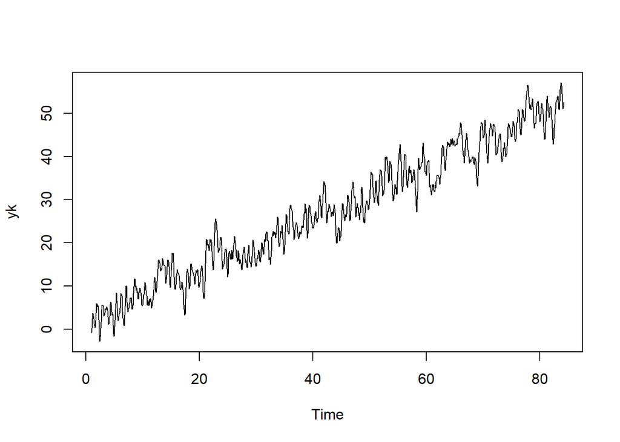

```r
library('forecast')

load('sarima_data.Rdata')

#Part 1

plot(yk)
```

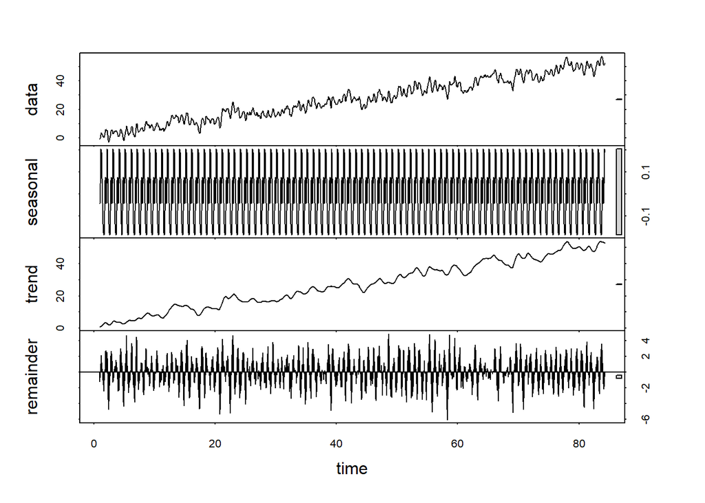

```r
plot(stl(yk,'per'))
```

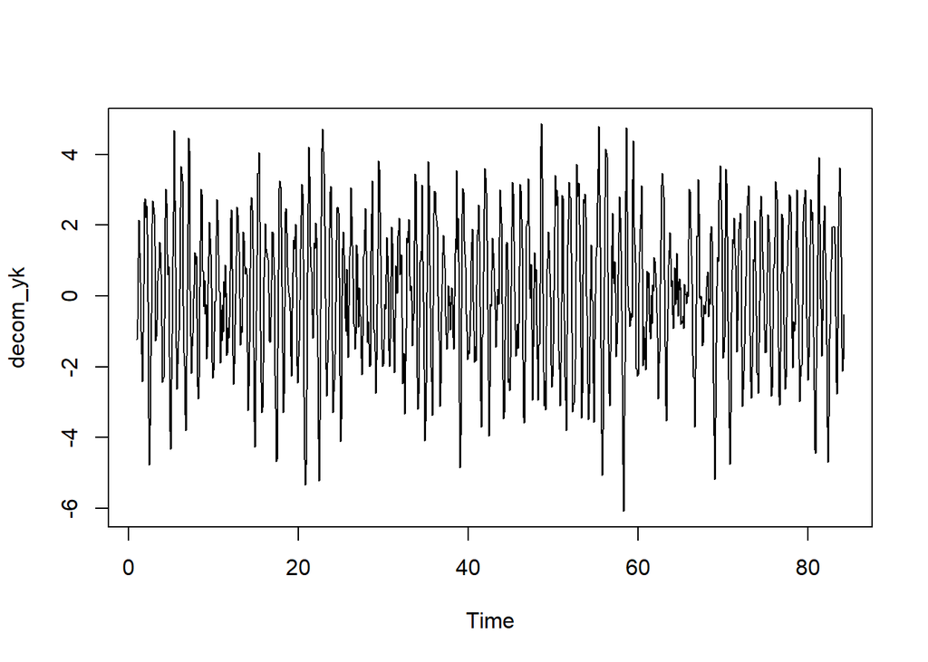

```r
decom_yk <- remainder(stl(yk,'per'))

plot(decom_yk)
```

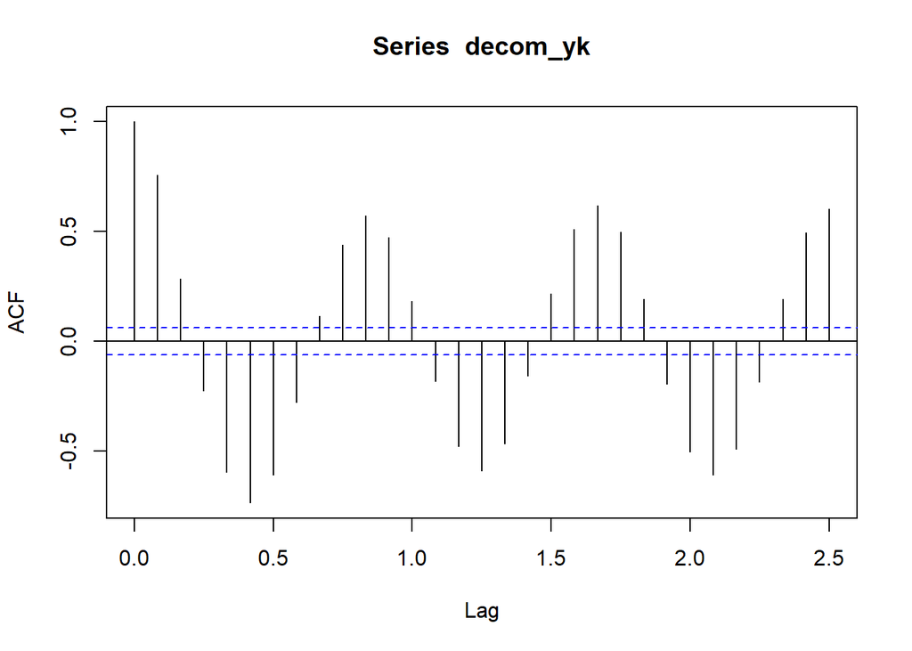

```r
acf(decom_yk)
```

We see that the dcomposed series is seasonal with a period of about 10. We further fit a cosine wave using **lm()** and then check for its residuals.

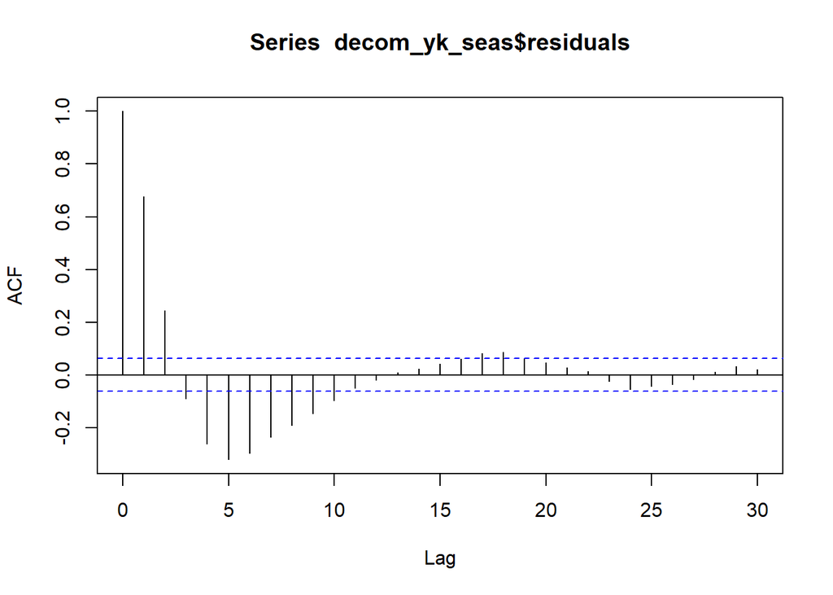

```r
tvec <- 1:1000

decom_yk_seas <- lm(decom_yk ~ I(sin(2*pi*(1/10)*tvec))+ I(cos(2*pi*(1/10)*tvec)))

acf(decom_yk_seas$residuals)
```

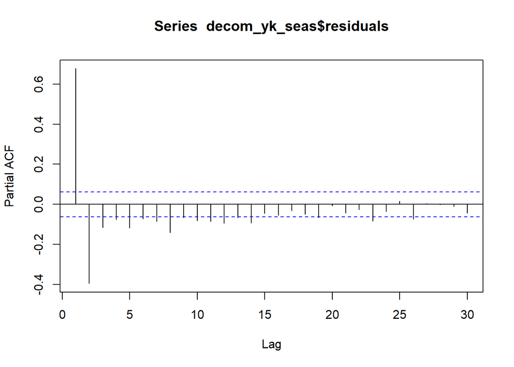

```r
pacf(decom_yk_seas$residuals)
```

The residuals clearly show that the series is AR(2) with respect to the PACF plot. Further fitting the AR(2) model

```r
ar2mod <- arima(decom_yk_seas$residuals,order=c(2,0,0))

ar2mod
```

```
##
## Call:
## arima(x = decom_yk_seas$residuals, order = c(2, 0, 0))
##
## Coefficients:
##          ar1      ar2  intercept
##       0.9434  -0.3940     0.0010
## s.e.  0.0290   0.0291     0.0592
##
## sigma^2 estimated as 0.7116:  log likelihood = -1249.31,  aic = 2506.63
```

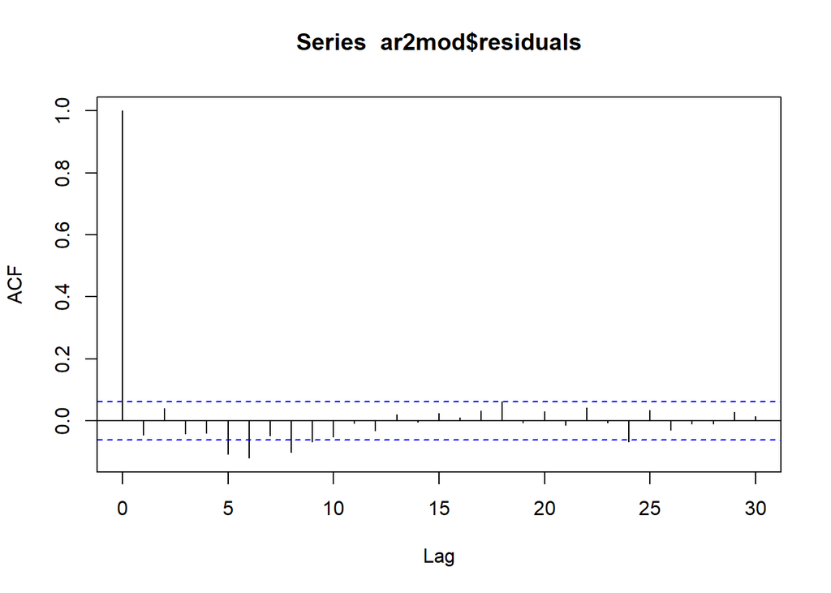

```r
acf(ar2mod$residuals)
```

$$v[k]=0.002798sin(0.2 \pi k) -1.374654cos(0.2 \pi k) + 0.9434*v[k-1] -0.3940*v[k-2] +e[k]$$
### Using SARIMA Models Now,

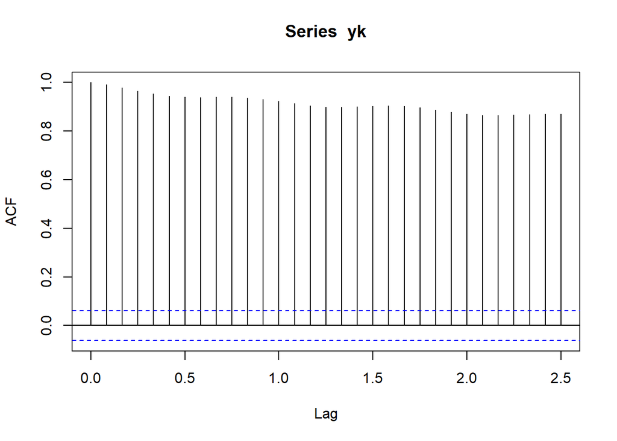

```r
#Part 2

acf(yk)
```

We see that the series clearly needs differencing. SO, after differencing once, we look at the acf of residuals and notice its periodicity of approximately 10.

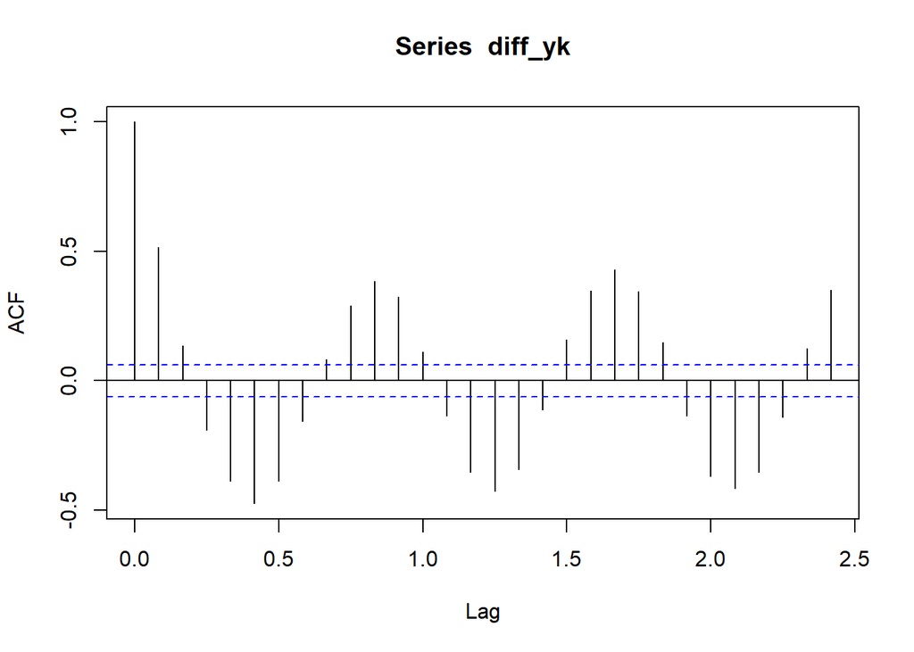

```r
diff_yk <- diff(yk)

acf(diff_yk)
```

I then simulated various SARIMA models with periodicity and checked which one satisfies underfit and overfit arguements. I concluded that AR(2) with SARIMA(1,1) is the best model. The ACF and PACF plots show the same.

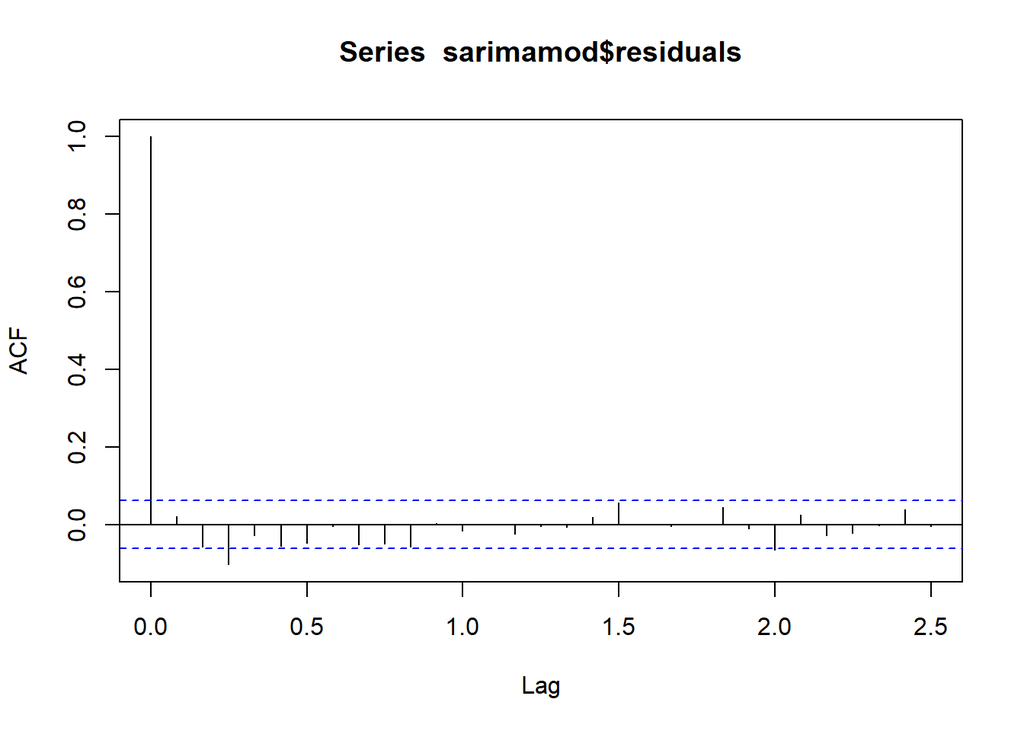

```r
sarimamod=arima(yk,order=c(2,0,0),seasonal=list(period=10,order=c(1,0,1)))

acf(sarimamod$residuals)
```

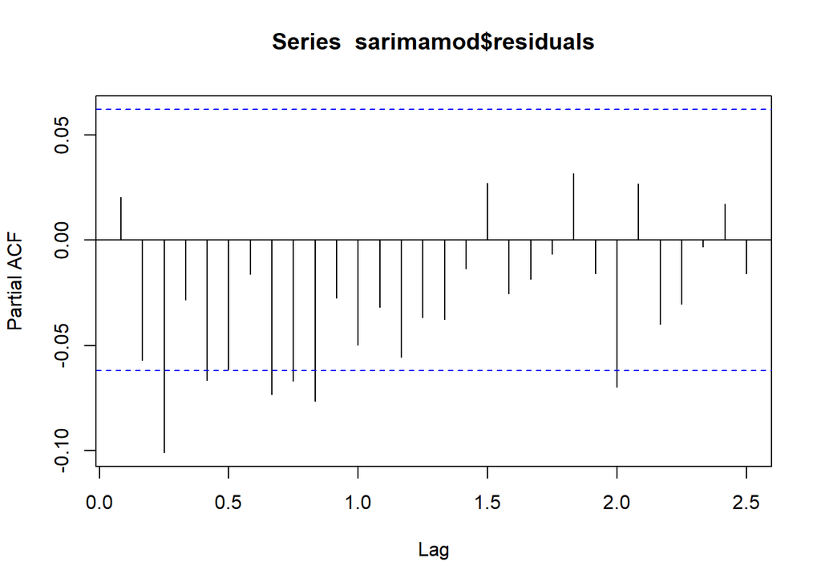

```r
pacf(sarimamod$residuals)
```

For a given sample set, suppose we have $X_i$ ranging from 1 to N, with $X_n$, for some n being the maximum value of the set. So,

$$P(X_i|\theta)=\frac{1}{\theta}$$
Assuming the events of picking a sample is independent.
$$f(X_1,X_2,X_3.....,X_N|\theta)=\frac{1}{\theta ^N}$$

$$l(\theta |N)=\frac{1}{\theta ^N}$$

$$L(\theta |N)=-N log \theta$$
NOw the log-likelihood function will take it’s maximum value at the minimum value of $\theta$. $\theta$ should atleast be greater or equal to the maximum value of sample set $X_n$.
$$\hat\theta=X_n$$

```r
load('mle_unif.Rdata')

max(xk)
```

```
## [1] 1.966975
```

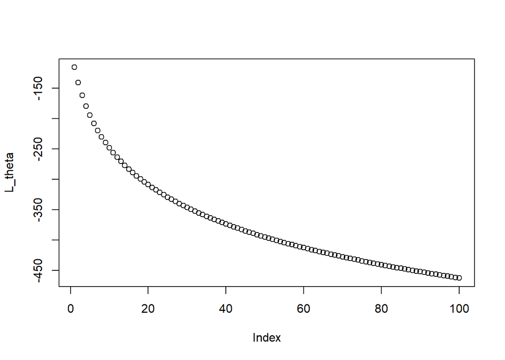

```r
theta = seq(max(xk),101, by=1)

L_theta={}

for (i in 1:100) {

    L_theta[i] = -100*(log(theta[i]))-(sum(xk)/theta[i])

}
plot(L_theta)
```

One can deduce the same from the graph of likelihood vs $\theta$.

Furthermore, we know that bias $\Delta \theta=E(\hat\theta)-\theta_0$, with $\theta_0$ being the truth. We see that for any x in [0,$\theta$] such that $x>= X_n, $the probability of this sample space over N samples become $P_{\theta}=(\frac{x}{\theta})^n.$

$$E(\hat\theta)=E(X_n)=\int_0^\theta P_{\theta}(X_n >=x) dx$$
$$E(X_n)=\int_0^\theta 1-(\frac{x}{\theta})^n dx=\theta-\frac{ \theta}{N+1}=\frac{N \theta}{N+1}$$
Hence,
$$Bias=\Delta \theta=E(\hat\theta)-\theta_0=\frac{N \theta}{N+1}-\theta=\frac{-\theta}{N +1}$$
Rather, if the distribution was uniform over $[0,\theta),$ we would have only got a limit tending to the maximum value $X_n$ for $\hat\theta$ which is not a right estimate for our subsequent bias calculation since this limit could become far away from the real $X_n.$ In order to solve this ambiguity, one can take large number of samples, then using the principles of consistency, one can say that the limit will tend to $X_n.$

## Fisher’s Information

For a given probability distribution function $f(y|\theta)$, we evaluate likelihood $l(\theta|y)$ which can be considered equal to the the probability distribution function.

In order to estimate the most efficient estimator, the estimator should satisfy the following condition,

$$\frac{S(\theta;y)}{I(\theta)}+\theta = \theta^*$$

In the above equation $^* $should only be a function of y, that is the data instants. With that in mind, let’s evaluate the two conditions given.

### $\lambda$ is the parameter

$$f(\lambda)=l(\lambda)=\lambda e^{-\lambda y}$$

$$L(\lambda) = log(l(\lambda))= log(\lambda)-\lambda y$$
$$S(\lambda;y)=\frac{\partial L}{\partial \theta}=\frac{\partial (log(\lambda)-\lambda y)}{\partial \lambda}=\frac{1}{\lambda}-y$$
$$I(\lambda)=-E\left((\frac{\partial L}{\partial \theta})^2 \right)=-E(\frac{-1}{\lambda^2})=\frac{1}{\lambda^2}$$
This implies,
$$\frac{S(\theta;y)}{I(\theta)}+\theta=\lambda-\lambda^2 y+\lambda = 2 \lambda-\lambda^2 y = \theta^*$$
Clearly, the most efficient estimator of $\lambda$ is a function of parameter itself, hence, it is not possible to determine the efficient estimator for $\lambda.$ Let’s try for a modified version of the same parameter.

### $\frac{1}{\lambda} =k$ is the parameter

$$f(k)=l(k)=\frac{e^{-y/k}}{k}$$
$$L(k)=log (l(k))=\frac{-y}{k}-log (k)$$
$$S(k;y)=\frac{\partial L(k)}{\partial k} = \frac{y}{k^2}-\frac{1}{k}$$
$$I(k)=-E\left( \frac{\partial ^2 L}{\partial k^2} \right)=-E\left( \frac{-2y}{k^3}+\frac{1}{k^2} \right)= \frac{1}{k^2}$$
This happens because since the process is white noise, so that makes $E(y)=\frac{1}{\lambda}=k$ since y is plotted on an exponential distribution. Now,
$$\frac{S(k;y)}{I(k)}+k=k^* = -k^2 \left( \frac{1}{k}-\frac{y}{k^2} \right) +k=y$$
As one can see, $k^*$ is purely a function of y, and hence it is the most efficient estimator for the given estimator.

## Variability of Sample Mean

For the vaiability of sample mean ($\sigma_\bar y^2$), we have for stationary data that has N realisations,

$$\sigma_\bar y^2= E((\bar y-E(\bar y))^2)=E(( \frac{1}{N} \Sigma_{k=0}^{N-1} y[k]-\mu _y)^2)=E(( \frac{1}{N} \Sigma_{k=0}^{N-1} (y[k]-\mu _y))^2)$$

$$\sigma_\bar y^2 = \frac{1}{N^2}E(\Sigma_{k=0}^{N-1} (y[k]-\mu _y))^2)+\frac{1}{N^2}E(\Sigma_{n=1}^N \Sigma_{m=1}^N (y[n]-\mu_y)(y[m]-\mu_y))$$
The first term in the above expression can be easily seen as the $\frac{\sigma[0]}{N}$, the second term where n is not equal to m can be shown as the auto-covariance function.

As, $\sigma[l]=\sigma[-l]$ for a stationary process, so it will suffice us to only take one side of the double summation, when $n<m$.

$$\sigma_\bar y^2 =\frac{\sigma[0]}{N}+\frac{2}{N^2}E(\Sigma_{n=0<m}^{N-1} (y[n]-\mu_y)(y[m]-\mu_y))$$
Now, let’s take $|n-m|=l$ as the lag for ACVF. For, l=1, we will see $\sigma[1]$ terms N-1 times, $\sigma[2]$ terms N-2 times and so on for $\sigma[l]$, we will see it N-l times. We can rewrite the above expression as

$$\sigma_\bar y^2 =\frac{\sigma[0]}{N}+\frac{2}{N^2}E(\Sigma_{l=1}^{N-1} (N-l)\sigma[l]$$
Hence,

$$\sigma_\bar y^2 =\frac{1}{N}(\sigma[0]+2E(\Sigma_{l=1}^{N-1} (1-\frac{l}{N})\sigma[l]$$

```r
N=5000 #no. of samples

#Generic method to calculate variance of sample mean estimator

mean_yk={}

for (i in 1:N){

  yk<-arima.sim(model=list(ma=0.4,order=c(0,0,1)),n=10000)
  mean_yk[i]=mean(yk)
}

hist(mean_yk)

var_1={}
for (i in 1:5000){
  var_1[i]=(mean(mean_yk)-mean_yk[i])^2
}

var_1=sum(mean_yk)/(N-1)

#Calculation using the proved expression

acvf_data = acf(yk,lag.max = 10000, type='cov')

acvf_yk = acvf_data$acf

sum_term=0

for (i in 2:10000){

  sum_term=sum_term+((1-(i/10000))*acvf_yk[i])
}

var_2 = (1/10000)*(acvf_yk[1]+(2*sum_term))
```

[output not shown]

The code written above simulates the given MA(1) model and I have evaluated variance with both the methods. Variance with the generic method comes out to be **4.149214e-05** and with our expression proved above, we get a variance of **1.728528e-05.** The values have a different scale altogether, but still are comparable to an extent that both are converging to 0 which is the general case for sample mean estimator. The variance would ideally converge to 0 as we increase the sample size to infinity.